# Ensemble Regression

As a last approach, we will try to fit an ensemble: In this ensemble, we will use both linear and nonlinear models along with kknn too, hoping to fit the non-linear relationships, what we have seen from earlier and push the model to separate customers, who didn’t spent next year from the others We will also use some preprocessing, like scaling and removing near zero variance predictors and clean the dataset from too outstanding values before training

```r
library(MASS)
library(car)
library(kknn)
library(mfp)
library(splines)
library(pscl)

source("R/utils.R")
source("R/RFM.R")
source("R/featureScaling.R")
source("R/modelFitting.R")

# Load customer rfm values
customer_rfm_2012 <- loadRFM(2012)
customer_rfm_2013 <- loadRFM(2013)

# Customer data, of spendings in 2012
customer_total_sales_2013 <- customer_rfm_2013 %>%
  dplyr::select(contact_id, total_sales) %>%
  rename(nexty_total_sales = total_sales)

customers_2012 <- left_join(customer_rfm_2012, customer_total_sales_2013, by = "contact_id") %>%
  mutate_each(funs(replace(., which(is.na(.)), 0)))
summary(customers_2012)
```

```
##   contact_id        days_since_last_purchase   order_num
##  Length:163953      Min.   :  0.0            Min.   :   1.000
##  Class :character   1st Qu.: 58.0            1st Qu.:   1.000
##  Mode  :character   Median :157.0            Median :   1.000
##                     Mean   :163.6            Mean   :   1.501
##                     3rd Qu.:258.0            3rd Qu.:   1.000
##                     Max.   :365.0            Max.   :2731.000
##   total_sales         product_num        active_days
##  Min.   :     0.00   Min.   :   1.000   Min.   :  0.00
##  1st Qu.:    32.95   1st Qu.:   1.000   1st Qu.:  0.00
##  Median :    64.86   Median :   1.000   Median :  0.00
##  Mean   :   124.70   Mean   :   1.825   Mean   : 22.68
##  3rd Qu.:   131.90   3rd Qu.:   2.000   3rd Qu.:  0.00
##  Max.   :181335.13   Max.   :1469.000   Max.   :365.00
##  nexty_total_sales
##  Min.   :     0.0
##  1st Qu.:     0.0
##  Median :     0.0
##  Mean   :    26.5
##  3rd Qu.:     0.0
##  Max.   :109480.9
```

## Preprocess data

### Remove near zero covariates and scale features

```r
print(pp <- preProcess(customers_2012[, -c(1, 7)],
                       method = c("nzv", "scale"),
                       outcome = customers_2012[, 7]))
```

```
## Created from 163953 samples and 5 variables
##
## Pre-processing:
##   - ignored (0)
##   - removed (1)
##   - scaled (4)
```

We can see, that active days was discarded and from the plot, that features are now scaled to a smaller range

```r
pp$method
```

```
## $scale
## [1] "days_since_last_purchase" "order_num"
## [3] "total_sales"              "product_num"
##
## $ignore
## character(0)
##
## $remove
## [1] "active_days"
```

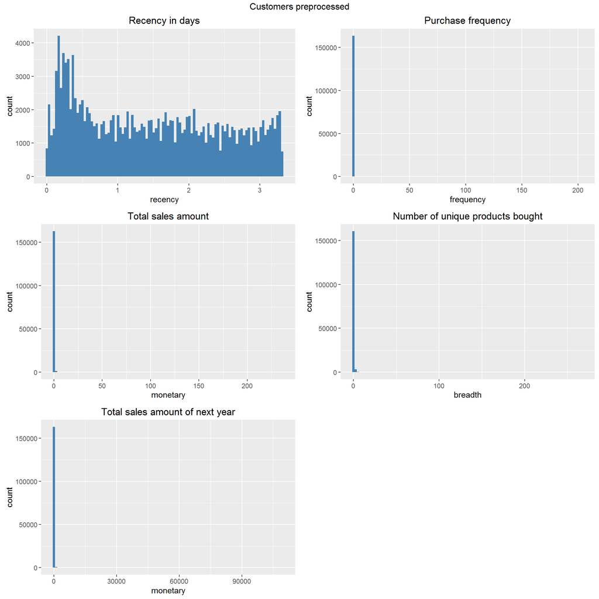

```r
pp_customers_2012 <- data.frame(contact_id = customers_2012[, 1],
                                 predict(pp, customers_2012[, -c(1,7)]),
                                 nexty_total_sales = customers_2012[, 7])

plotRfms(pp_customers_2012, c(100, 100, 100, 100, 100, 100), "rfmbn", "Customers preprocessed")
```

### Discarde points with too high leverage, influence

(in a linear model)

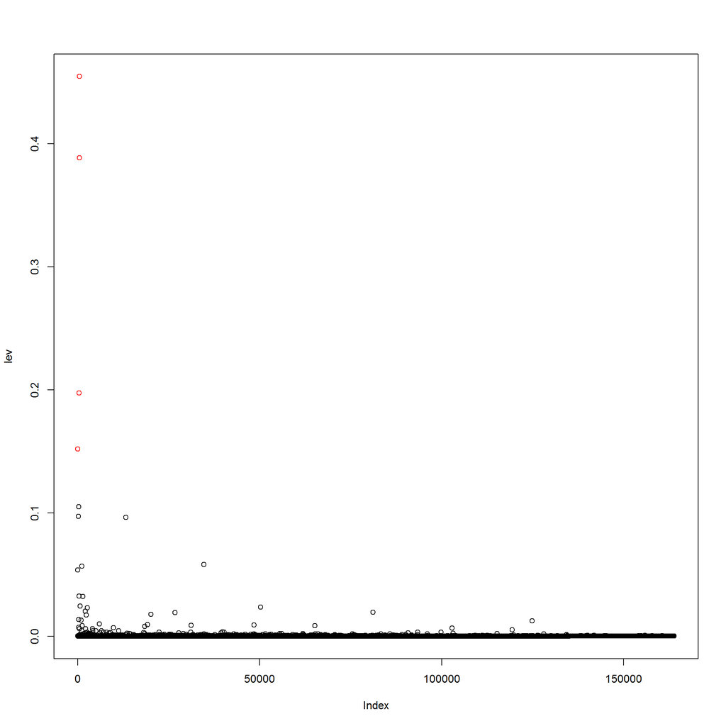

```r
set.seed(32)
glm_model <- glm(nexty_total_sales ~ order_num + product_num + total_sales + days_since_last_purchase,
                    data = pp_customers_2012)

lev <- hat(model.matrix(glm_model))
plot(lev)
high_leverage_points <- as.numeric(row.names(pp_customers_2012[lev > 0.15,]))
points(high_leverage_points, lev[high_leverage_points], col = 'red')
```

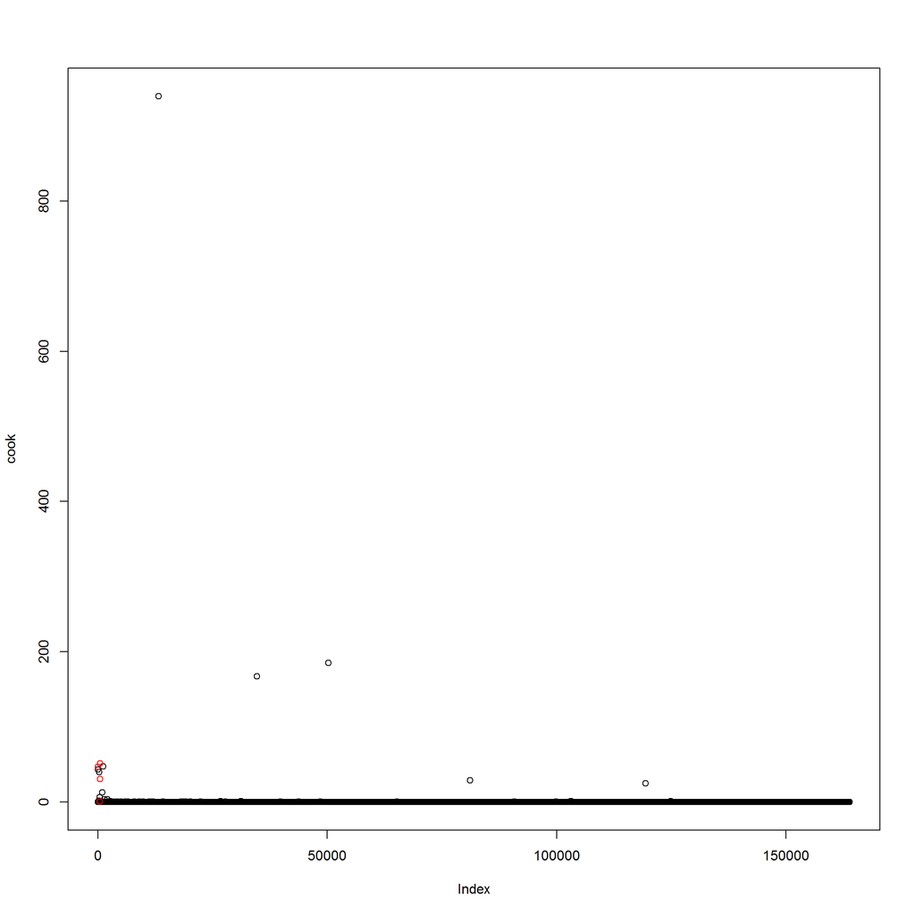

```r
cook <- cooks.distance(glm_model)
plot(cook)
points(high_leverage_points, cook[high_leverage_points], col = 'red')
```

```r
high_influence_points <- as.numeric(row.names(pp_customers_2012[cook > 150,]))

outliners <- union(high_influence_points, high_leverage_points)
pp_customers_2012[outliners,]
```

```
##       contact_id days_since_last_purchase order_num total_sales
## 13199   46092347              0.009082532  84.82951   101.68455
## 34642   19397257              0.000000000  68.87738    75.76914
## 50257   32421253              0.009082532  21.99007    37.96558
## 9       35117040              0.000000000 115.69015   101.59715
## 343     25315468              0.000000000 124.63527    82.58667
## 462     35244243              0.000000000 203.57591   236.34003
## 488     49141897              0.000000000 193.95991   166.53308
##       product_num nexty_total_sales
## 13199   122.16685         109480.94
## 34642    96.89722             54.32
## 50257    27.81477          76223.77
## 9        28.90555          32752.18
## 343      32.54147          37829.00
## 462     267.05819         104799.63
## 488      56.35673          66869.82
```

```r
pp_customers_2012 <- pp_customers_2012[-outliners,]
```

## Train

For the ensemble we will use the following 4 models:

- Gaussian linear model
- Multiple Fractional Polynomial model
- Polynomial Splines
- Weighted k-Nearest Neighbor Regression model (for 2 clusters)

```r
set.seed(3456)
trainIndex <- createDataPartition(pp_customers_2012$nexty_total_sales, p = .8,
                                  list = FALSE,
                                  times = 1)

customer_purchase_train <- pp_customers_2012[ trainIndex,]
customer_purchase_test  <- pp_customers_2012[-trainIndex,]
```

```r
set.seed(32)
summary(glm_model <- glm(nexty_total_sales ~ order_num + product_num + total_sales + days_since_last_purchase,
                         data = customer_purchase_train))
```

```
##
## Call:
## glm(formula = nexty_total_sales ~ order_num + product_num + total_sales +
##     days_since_last_purchase, data = customer_purchase_train)
##
## Deviance Residuals:
##      Min        1Q    Median        3Q       Max
## -16165.7     -22.3     -10.0       0.9   26518.8
##
## Coefficients:
##                          Estimate Std. Error t value Pr(>|t|)
## (Intercept)               -0.5535     0.8781   -0.63    0.528
## order_num                316.1335     2.0813  151.89   <2e-16 ***
## product_num              -71.2236     1.2682  -56.16   <2e-16 ***
## total_sales              144.8012     1.8296   79.14   <2e-16 ***
## days_since_last_purchase  -6.1665     0.4479  -13.77   <2e-16 ***
## ---
## Signif. codes:  0 '***' 0.001 '**' 0.01 '*' 0.05 '.' 0.1 ' ' 1
##
## (Dispersion parameter for gaussian family taken to be 25730.83)
##
##     Null deviance: 8113558410  on 131156  degrees of freedom
## Residual deviance: 3374649664  on 131152  degrees of freedom
## AIC: 1704172
##
## Number of Fisher Scoring iterations: 2
```

#### Multiple Fractional Polynomial model

```r
set.seed(32)
summary(mfp_model <- mfp(nexty_total_sales ~ fp(order_num) + fp(product_num) + fp(total_sales) + fp(days_since_last_purchase),
                         data = customer_purchase_train))
```

```
##
## Call:
## glm(formula = nexty_total_sales ~ I((order_num/0.1)^1) + I((order_num/0.1)^3) +
##     I(product_num^2) + I(product_num^2 * log(product_num)) +
##     I(((total_sales + 0.1)/0.1)^2) + I(((total_sales + 0.1)/0.1)^2 *
##     log(((total_sales + 0.1)/0.1))) + I((days_since_last_purchase +
##     0.1)^-2) + I((days_since_last_purchase + 0.1)^1), data = customer_purchase_train)
##
## Deviance Residuals:
##      Min        1Q    Median        3Q       Max
## -11611.2     -17.7     -10.4      -6.9   19158.6
##
## Coefficients:
##                                                                   Estimate
## (Intercept)                                                     -1.121e+00
## I((order_num/0.1)^1)                                             1.505e+01
## I((order_num/0.1)^3)                                             1.161e-04
## I(product_num^2)                                                 1.780e+01
## I(product_num^2 * log(product_num))                             -5.432e+00
## I(((total_sales + 0.1)/0.1)^2)                                   5.515e-01
## I(((total_sales + 0.1)/0.1)^2 * log(((total_sales + 0.1)/0.1))) -8.254e-02
## I((days_since_last_purchase + 0.1)^-2)                           5.470e-01
## I((days_since_last_purchase + 0.1)^1)                           -2.088e+00
##                                                                 Std. Error
## (Intercept)                                                      9.336e-01
## I((order_num/0.1)^1)                                             3.406e-01
## I((order_num/0.1)^3)                                             1.326e-06
## I(product_num^2)                                                 3.352e-01
## I(product_num^2 * log(product_num))                              7.719e-02
## I(((total_sales + 0.1)/0.1)^2)                                   7.281e-03
## I(((total_sales + 0.1)/0.1)^2 * log(((total_sales + 0.1)/0.1)))  1.181e-03
## I((days_since_last_purchase + 0.1)^-2)                           4.281e-02
## I((days_since_last_purchase + 0.1)^1)                            4.397e-01
##                                                                 t value
## (Intercept)                                                      -1.201
## I((order_num/0.1)^1)                                             44.186
## I((order_num/0.1)^3)                                             87.564
## I(product_num^2)                                                 53.115
## I(product_num^2 * log(product_num))                             -70.377
## I(((total_sales + 0.1)/0.1)^2)                                   75.746
```

[output cut: 18 more lines]

```
## I(product_num^2 * log(product_num))                             ***
## I(((total_sales + 0.1)/0.1)^2)                                  ***
## I(((total_sales + 0.1)/0.1)^2 * log(((total_sales + 0.1)/0.1))) ***
## I((days_since_last_purchase + 0.1)^-2)                          ***
## I((days_since_last_purchase + 0.1)^1)                           ***
## ---
## Signif. codes:  0 '***' 0.001 '**' 0.01 '*' 0.05 '.' 0.1 ' ' 1
##
## (Dispersion parameter for gaussian family taken to be 19784.87)
##
##     Null deviance: 8113558410  on 131156  degrees of freedom
## Residual deviance: 2594746122  on 131148  degrees of freedom
## AIC: 1669712
##
## Number of Fisher Scoring iterations: 2
```

#### Polynomial Splines

```r
set.seed(32)
summary(spline_model <- lm(nexty_total_sales ~ bs(order_num) + bs(product_num) + bs(total_sales) + bs(days_since_last_purchase),
                         data = customer_purchase_train))
```

```
##
## Call:
## lm(formula = nexty_total_sales ~ bs(order_num) + bs(product_num) +
##     bs(total_sales) + bs(days_since_last_purchase), data = customer_purchase_train)
##
## Residuals:
##      Min       1Q   Median       3Q      Max
## -11064.6    -17.4     -6.9     -2.2  20106.3
##
## Coefficients:
##                                 Estimate Std. Error  t value Pr(>|t|)
## (Intercept)                    1.521e+01  1.417e+00   10.734  < 2e-16 ***
## bs(order_num)1                 1.217e+04  2.086e+02   58.351  < 2e-16 ***
## bs(order_num)2                -8.042e+03  1.411e+03   -5.700 1.20e-08 ***
## bs(order_num)3                 2.650e+05  5.016e+03   52.833  < 2e-16 ***
## bs(product_num)1              -3.151e+01  6.817e+01   -0.462   0.6440
## bs(product_num)2               1.515e+04  8.682e+02   17.452  < 2e-16 ***
## bs(product_num)3              -1.792e+05  1.791e+03 -100.055  < 2e-16 ***
## bs(total_sales)1               2.787e+03  8.939e+01   31.177  < 2e-16 ***
## bs(total_sales)2               4.308e+04  1.210e+03   35.600  < 2e-16 ***
## bs(total_sales)3              -4.162e+04  5.041e+03   -8.255  < 2e-16 ***
## bs(days_since_last_purchase)1 -3.126e+01  4.394e+00   -7.114 1.13e-12 ***
## bs(days_since_last_purchase)2 -6.877e+00  2.927e+00   -2.349   0.0188 *
## bs(days_since_last_purchase)3 -1.734e+01  2.371e+00   -7.316 2.57e-13 ***
## ---
## Signif. codes:  0 '***' 0.001 '**' 0.01 '*' 0.05 '.' 0.1 ' ' 1
##
## Residual standard error: 142.4 on 131144 degrees of freedom
## Multiple R-squared:  0.6724, Adjusted R-squared:  0.6723
## F-statistic: 2.243e+04 on 12 and 131144 DF,  p-value: < 2.2e-16
```

#### Weighted k-Nearest Neighbor Regression model

```r
set.seed(32)
summary(kknn_model <- train.kknn(nexty_total_sales ~ order_num + product_num + total_sales + days_since_last_purchase,
                                 data = customer_purchase_train,
                                 ks = c(2)))
```

```
##
## Call:
## train.kknn(formula = nexty_total_sales ~ order_num + product_num +     total_sales + days_since_last_purchase, data = customer_purchase_train,     ks = c(2))
##
## Type of response variable: continuous
## minimal mean absolute error: 35.05516
## Minimal mean squared error: 56327.98
## Best kernel: optimal
## Best k: 2
```

### Predict test data

```r
testData_glm <- cbind(customer_purchase_test, fit = predict(glm_model, customer_purchase_test, type = "response"))
testData_mfp <- cbind(customer_purchase_test, fit = predict(mfp_model, customer_purchase_test, type = "response"))
testData_spline <- cbind(customer_purchase_test, fit = predict(spline_model, customer_purchase_test))
testData_kknn <- cbind(customer_purchase_test, fit = predict(kknn_model, customer_purchase_test))
```

#### Get weights for ensemble with minimizing the RMSE

The ensebmle optimizes for RMSE with a weighted mean calculation of the training results of each model

```r
set.seed(32)
ens_weights <- optimiseEnsemble(fitted1 = glm_model$fitted.values,
                                fitted2 = mfp_model$fitted.values,
                                fitted3 = spline_model$fitted.values,
                                fitted4 = unlist(kknn_model$fitted.values),
                                actual = glm_model$y)$par
ens_weights
```

```
## [1] 1.0 1.0 1.0 0.5
```

### Calculating differences in predicted and actual data

We can see, that all models did pretty good (compared to earlier models) both regarding the RMSE and the actual difference

```r
glm_test_RMSE <- calculateRMSEFromFit(testData_glm)
glm_test_diff <- calculateDiffFromModel(testData_glm)
glm_test_diff_perc <- calculateDiffFromModel(testData_glm) * 100 / sum(testData_glm$nexty_total_sales)
print(paste("RMSE:", glm_test_RMSE, ", diff:", glm_test_diff, ",diff(%):", glm_test_diff_perc))
```

```
## [1] "RMSE: 316.498731930684 , diff: -55038.0435856442 ,diff(%): -6.57596878827748"
```

```r
mfp_test_RMSE <- calculateRMSEFromFit(testData_mfp)
mfp_test_diff <- calculateDiffFromModel(testData_mfp)
mfp_test_diff_perc <- calculateDiffFromModel(testData_mfp) * 100 / sum(testData_mfp$nexty_total_sales)
print(paste("RMSE:", mfp_test_RMSE, ", diff:", mfp_test_diff, ",diff(%):", mfp_test_diff_perc))
```

```
## [1] "RMSE: 495.804585306086 , diff: 32549.1128169073 ,diff(%): 3.88898180286942"
```

```r
spline_test_RMSE <- calculateRMSEFromFit(testData_spline)
spline_test_diff <- calculateDiffFromModel(testData_spline)
spline_test_diff_perc <- calculateDiffFromModel(testData_spline) * 100 / sum(testData_spline$nexty_total_sales)
print(paste("RMSE:", spline_test_RMSE, ", diff:", spline_test_diff, ",diff(%):", spline_test_diff_perc))
```

```
## [1] "RMSE: 523.173874538862 , diff: 36723.7224285647 ,diff(%): 4.38776592964865"
```

```r
kknn_test_RMSE <- calculateRMSEFromFit(testData_kknn)
kknn_test_diff <- calculateDiffFromModel(testData_kknn)
kknn_test_diff_perc <- calculateDiffFromModel(testData_kknn) * 100 / sum(testData_kknn$nexty_total_sales)
print(paste("RMSE:", kknn_test_RMSE, ", diff:", kknn_test_diff, ",diff(%):", kknn_test_diff_perc))
```

```
## [1] "RMSE: 317.388659273136 , diff: -50541.4674230264 ,diff(%): -6.03871596144916"
```

From the results we can see, that the ensemble did also pretty good both regarding the RMSE and especially in the accuracy in predicting the next years revenue

```r
testData_ensemble <- data.frame(testData_glm[, c(1:6)],
                                fit = ensembleFun(testData_glm$fit, testData_mfp$fit, testData_spline$fit, testData_kknn$fit, ens_weights))
ens_test_RMSE <- calculateRMSEFromFit(testData_ensemble)
ens_test_diff <- calculateDiffFromModel(testData_ensemble)
ens_test_diff_perc <- calculateDiffFromModel(testData_ensemble) * 100 / sum(testData_ensemble$nexty_total_sales)
print(paste("RMSE:", ens_test_RMSE, ", diff:", ens_test_diff, ",diff(%):", ens_test_diff_perc))
```

```
## [1] "RMSE: 392.480071142748 , diff: -3153.12630048154 ,diff(%): -0.376736867566851"
```

Next, we will train for the whole dataset and test the ensemble for some customer groups

### Train on whole dataset

```r
set.seed(32)
final_model_glm <-glm(nexty_total_sales ~ order_num + product_num + total_sales + days_since_last_purchase,
                      data = pp_customers_2012)
set.seed(32)
final_model_mfp <- mfp(nexty_total_sales ~ fp(order_num) + fp(product_num) + fp(total_sales) + fp(days_since_last_purchase),
                        data = pp_customers_2012)
set.seed(32)
final_model_spline <- lm(nexty_total_sales ~ bs(order_num) + bs(product_num) + bs(total_sales) + bs(days_since_last_purchase),
                                data = pp_customers_2012)
set.seed(32)
final_model_kknn <- train.kknn(nexty_total_sales ~ order_num + product_num + total_sales + days_since_last_purchase,
                                       data = pp_customers_2012,
                                       ks = c(2))
```

### Test customer groups

We will test on the same two customer groups as before: customers who purchased in december and “onetime” customers (order_num == 1)

#### Dec customers

Filter december customers, predict next years revenue and optimise ensemble weights

```r
pp_dec_customers <- pp_customers_2012 %>%
  filter(days_since_last_purchase < 31)

decData_fitted_glm <- cbind(pp_dec_customers, fit = predict(final_model_glm, pp_dec_customers, type = "response"))
decData_fitted_mfp <- cbind(pp_dec_customers, fit = predict(final_model_mfp, pp_dec_customers, type = "response"))
decData_fitted_spline <- cbind(pp_dec_customers, fit = predict(final_model_spline, pp_dec_customers))
decData_fitted_kknn <- cbind(pp_dec_customers, fit = predict(final_model_kknn, pp_dec_customers))

ens_weights <- optimiseEnsemble(fitted1 = final_model_glm$fitted.values,
                                fitted2 = final_model_mfp$fitted.values,
                                fitted3 = final_model_spline$fitted.values,
                                fitted4 = unlist(final_model_kknn$fitted.values),
                                actual = final_model_glm$y)$par
ens_weights
```

```
## [1] 1.0 1.0 1.0 0.5
```

Calculate ensemble result and calculate error, accuracy

```r
decData_fitted_ens <- data.frame(decData_fitted_glm[, c(1:6)],
                                fit = ensembleFun(decData_fitted_glm$fit, decData_fitted_mfp$fit, decData_fitted_spline$fit, decData_fitted_kknn$fit,
                                                  ens_weights))

# Sum of differences, RMSE and % in dec customers
ens_dec_RMSE <- calculateRMSEFromFit(decData_fitted_ens)
ens_dec_diff <- calculateDiffFromModel(decData_fitted_ens)
ens_dec_diff_perc <- calculateDiffFromModel(decData_fitted_ens) * 100 / sum(decData_fitted_ens$nexty_total_sales)
print(paste("RMSE:", ens_dec_RMSE, ", diff:", ens_dec_diff, ",diff(%):", ens_dec_diff_perc))
```

```
## [1] "RMSE: 168.98043580919 , diff: -3135.29518559345 ,diff(%): -0.0800509483998768"
```

We can see, that the ensemble model had even better results on this customer group with an almost 100% accuracy :)

### “Onetime” customers

Filter onetime customers and predict next years revenue

```r
order_min_scaled <- min(pp_customers_2012$order_num)
onetime_customers <- pp_customers_2012 %>%
  filter(order_num == order_min_scaled)


onetimeData_fitted_glm <- cbind(onetime_customers, fit = predict(final_model_glm, onetime_customers, type = "response"))
onetimeData_fitted_mfp <- cbind(onetime_customers, fit = predict(final_model_mfp, onetime_customers, type = "response"))
onetimeData_fitted_spline <- cbind(onetime_customers, fit = predict(final_model_spline, onetime_customers))
onetimeData_fitted_kknn <- cbind(onetime_customers, fit = predict(final_model_kknn, onetime_customers))
```

Calculate ensemble result and calculate error, accuracy

```r
onetimeData_fitted_ens <- data.frame(onetimeData_fitted_glm[, c(1:6)],
                                 fit = ensembleFun(onetimeData_fitted_glm$fit, onetimeData_fitted_mfp$fit, onetimeData_fitted_spline$fit, onetimeData_fitted_kknn$fit,
                                                   ens_weights))

# Sum of differences, RMSE and % in onetime customers
ens_onetime_RMSE <- calculateRMSEFromFit(onetimeData_fitted_ens)
ens_onetime_diff <- calculateDiffFromModel(onetimeData_fitted_ens)
ens_onetime_diff_perc <- calculateDiffFromModel(onetimeData_fitted_ens) * 100 / sum(onetimeData_fitted_ens$nexty_total_sales)
print(paste("RMSE:", ens_onetime_RMSE, ", diff:", ens_onetime_diff, ",diff(%):", ens_onetime_diff_perc))
```

```
## [1] "RMSE: 58.8402825858618 , diff: -308350.985646732 ,diff(%): -20.245413390929"
```

**So far, this is the best model, so we will choose it for prediction and create an interface for accessing it and predict new data with it**

## Save model and related data

Save preprocessed customer data for both 2012 and 2013

```r
pp_customers_2012 <- data.frame(contact_id = customers_2012[, 1],
                                predict(pp, customers_2012[, -c(1,7)]),
                                nexty_total_sales = customers_2012[, 7])
write.csv(pp_customers_2012, "data/RFM_pp_2012.csv", row.names = F, quote = F)

pp_customers_2013 <- data.frame(contact_id = customer_rfm_2013[, 1],
                                predict(pp, customer_rfm_2013[, -1]))
write.csv(pp_customers_2013, "data/RFM_pp_2013.csv", row.names = F, quote = F)
```

Save models and ensemble weights

```r
saveRDS(final_model_glm, file = "data/model/final_glm.rds")
saveRDS(final_model_mfp, file = "data/model/final_mfp.rds")
saveRDS(final_model_spline, file = "data/model/final_spline.rds")
saveRDS(final_model_kknn, file = "data/model/final_kknn.rds")
saveRDS(ens_weights, file = "data/model/ens_weights.rds")
```

## Save results

```r
glm_results <- createModelSummary(description = "Gaussian linear regression, scaled features, formula = nexty_total_sales ~ order_num + product_num + total_sales + days_since_last_purchase",
                                  test_RMSE = glm_test_RMSE,
                                  test_diff = glm_test_diff,
                                  test_diff_percent = glm_test_diff_perc)
saveRDS(glm_results, file = "data/results/glm.rds")

mfp_results <- createModelSummary(description = "Multiple Fractional Polynomial model, scaled features, formula = nexty_total_sales ~ order_num + product_num + total_sales + days_since_last_purchase",
                                  test_RMSE = mfp_test_RMSE,
                                  test_diff = mfp_test_diff,
                                  test_diff_percent = mfp_test_diff_perc)
saveRDS(mfp_results, file = "data/results/mfp.rds")

spline_results <- createModelSummary(description = "Polynomial Splines, scaled features, formula = nexty_total_sales ~ order_num + product_num + total_sales + days_since_last_purchase",
                                    test_RMSE = spline_test_RMSE,
                                    test_diff = spline_test_diff,
                                    test_diff_percent = spline_test_diff_perc)
saveRDS(spline_results, file = "data/results/spline.rds")

kknn_results <- createModelSummary(description = "Polynomial Splines, scaled features, formula = nexty_total_sales ~ order_num + product_num + total_sales + days_since_last_purchase",
                                   test_RMSE = kknn_test_RMSE,
                                   test_diff = kknn_test_diff,
                                   test_diff_percent = kknn_test_diff_perc)
saveRDS(kknn_results, file = "data/results/kknn.rds")

ens_results <- createModelSummary(description = "Ensemble of (gml, mfp, splines), formula = nexty_total_sales ~ order_num + product_num + total_sales + days_since_last_purchase",
                                   test_RMSE = ens_test_RMSE,
                                   test_diff = ens_test_diff,
                                   test_diff_percent = ens_test_diff_perc,
                                  dec_test_RMSE = ens_dec_RMSE,
                                  dec_test_diff = ens_dec_diff,
                                  dec_test_diff_percent = ens_dec_diff_perc,
                                  onetime_test_RMSE = ens_onetime_RMSE,
                                  onetime_test_diff = ens_onetime_diff,
                                  onetime_test_diff_percent = ens_onetime_diff_perc)
saveRDS(ens_results, file = "data/results/ens.rds")
```